# Stat 380 Final Project

### Scree Plot (Maltreatment Type Data)

```
Ignoring unknown parameters: type
```

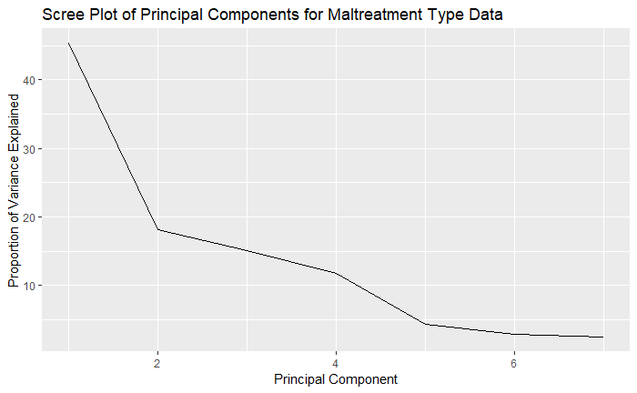

```r
mal_pve <-
  data.frame(sd = mal_pca$sdev) %>%
  rownames_to_column() %>%
  mutate(rowname = parse_number(rowname),
         totalVar = sum(mal_pca$sdev^2),
         pve = 100 * sd^2 / totalVar,
         cusum = cumsum(pve))
# scree plot
mal_pve %>%
  ggplot(aes(x = rowname, y = pve)) +
  geom_line(type = 3) +
  xlab("Principal Component") +
  ylab("Proportion of Variance Explained") +
  ggtitle("Scree Plot of Principal Components for Maltreatment Type Data")
```

The plot above shows that ~ 4 components explains around 89% variance in the data set. In order words, using PCA we have reduced 7 predictors to 4 without compromising much on explained variance. This is the power of PCA. Let’s confirm by plotting a cumulative variance plot. This will give us a clear picture of number of components.

```
Ignoring unknown parameters: type
```

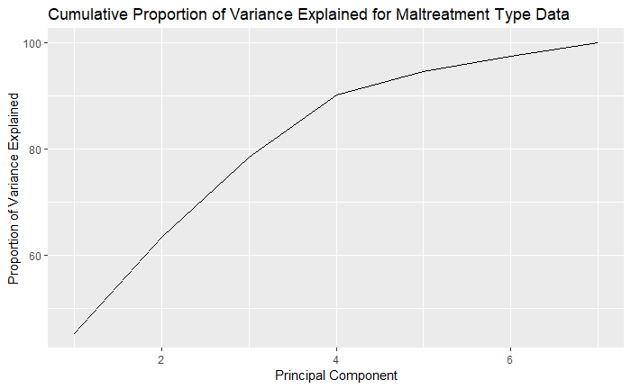

```r
# cumulative PVE plot
mal_pve %>%
  ggplot(aes(x = rowname, y = cusum)) +
  geom_line(type = 3) +
  xlab("Principal Component") +
  ylab("Proportion of Variance Explained") +
  ggtitle("Cumulative Proportion of Variance Explained for Maltreatment Type Data")
```

## Data Analysis

### Statistical Modeling

#### Data Preparation

```r
# set RNG seed for reproducible results
set.seed(622)
# partition the data
n <- nrow(perpetrator_total)
test_idx <-
  sample.int(n, size = round(0.25 * n))  # select row numbers for the test set
train <-
  perpetrator_total[-test_idx, ]  # exclude the test set cases
nrow(train)
```

```
[1] 38
```

```r
test <- perpetrator_total[test_idx, ]    # test set cases only
nrow(test)
```

```
[1] 12
```

Here we have made a test data set and viewed how many rows the set had.

#### Moving on with test analysis

Normally with statistical modeling you would use a training set to create a model to predict events or occurences. Once that model has its finishing touches, one would use all the data provided to make a final test run through the model and make predictive conclusions. We made the decision not to move on with our analysis and predictive modeling due to ethicical reasoning. We feel that predicting a negative topic such as child abuse could be hurtful and sensitive to some people. We also were not given permission to predict things such as this and would not be using our coding “power” for a greater good by possibly promoting more abuse.